# Session 1: Transformation into Stationarity

### I. Exploratory data analysis and transformation into stationarity

#### Ia. Exploratory data analysis

Import the data

```r
(serie=ts((read.table("gdpUSA.dat",header=F)),start=1947,freq=4))
```

```
##         Qtr1    Qtr2    Qtr3    Qtr4
## 1947  2033.1  2027.6  2023.5  2055.1
## 1948  2086.0  2120.5  2132.6  2135.0
## 1949  2105.6  2098.4  2120.0  2102.3
## 1950  2184.9  2251.5  2338.5  2383.3
## 1951  2415.7  2457.5  2508.2  2513.7
## 1952  2540.6  2546.0  2564.4  2648.6
## 1953  2697.9  2718.7  2703.4  2662.5
## 1954  2649.8  2652.6  2682.6  2735.1
## 1955  2813.2  2859.0  2897.6  2915.0
## 1956  2903.7  2927.7  2925.0  2973.2
## 1957  2992.2  2985.7  3014.9  2983.7
## 1958  2906.3  2925.4  2993.1  3063.1
## 1959  3121.9  3192.4  3194.7  3203.8
## 1960  3275.8  3258.1  3274.0  3232.0
```

[output cut: 59 more lines]

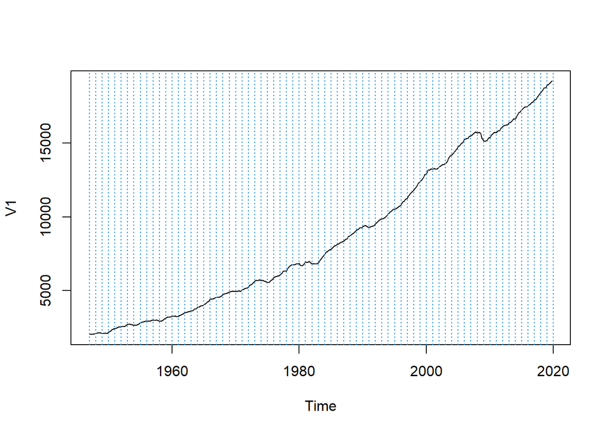

```r
plot(serie)
abline(v=1947:2020,col=4,lty=3)
abline(h=0)
```

#### Ib. Tranforming series into a stationary one:

Is Variance constant?

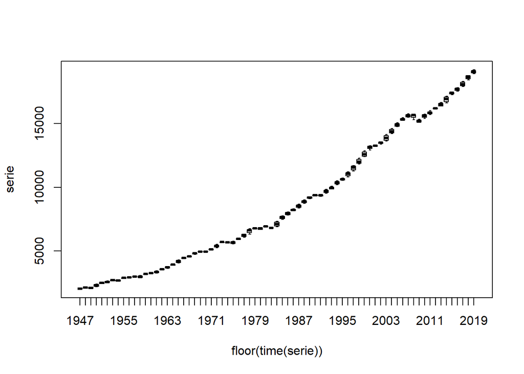

```r
boxplot(serie~floor(time(serie)))
```

Boxplots with only 4 observations? Better group observations of 2-3 years (8-12 quarters)?

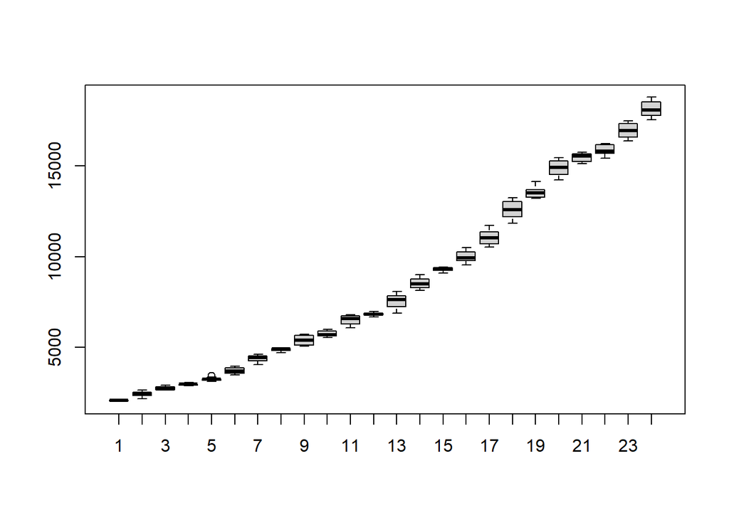

```r
groupedserie <- matrix(serie[1:(24*12)],ncol=24) #12 quarters=3yrs together=ncol=12
boxplot(groupedserie)
```

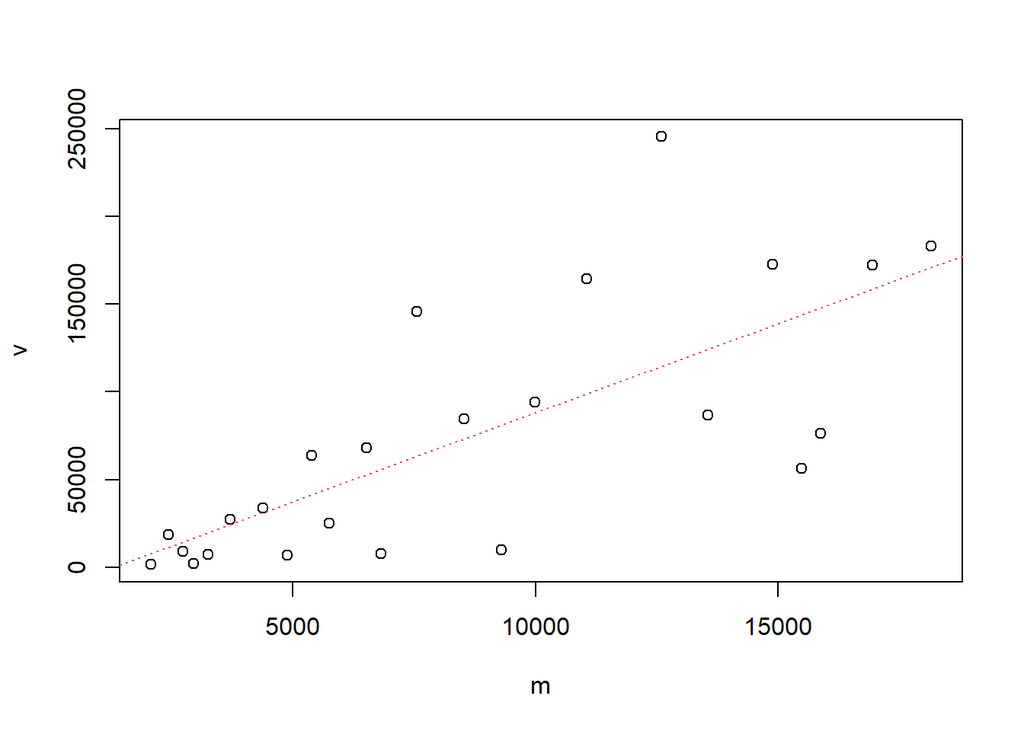

```r
m<-apply(groupedserie,2,mean)
v<-apply(groupedserie,2,var)
plot(v~m)
abline(lm(v~m),col=2,lty=3)
```

Thus, … the varianza is not considered constant! So, we change the scale by applying logarithms

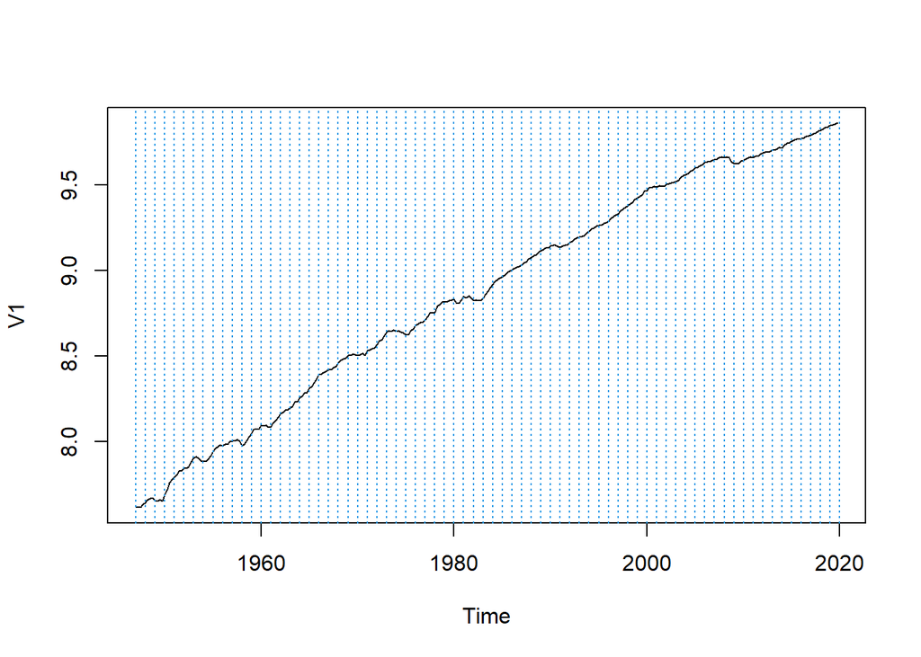

```r
lnserie=log(serie)
plot(lnserie)
abline(v=1947:2020,col=4,lty=3)
abline(h=0)
```

Let’s check the same plots for the transformed series

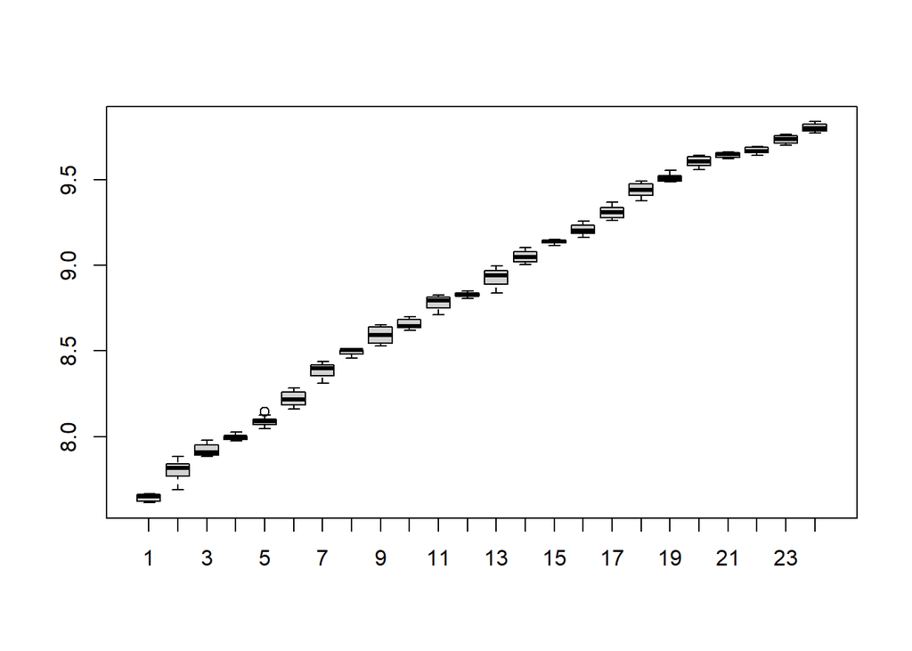

```r
groupedlnserie <- matrix(lnserie[1:(24*12)],ncol=24) #12 quarters=3yrs together=ncol=12
boxplot(groupedlnserie)
```

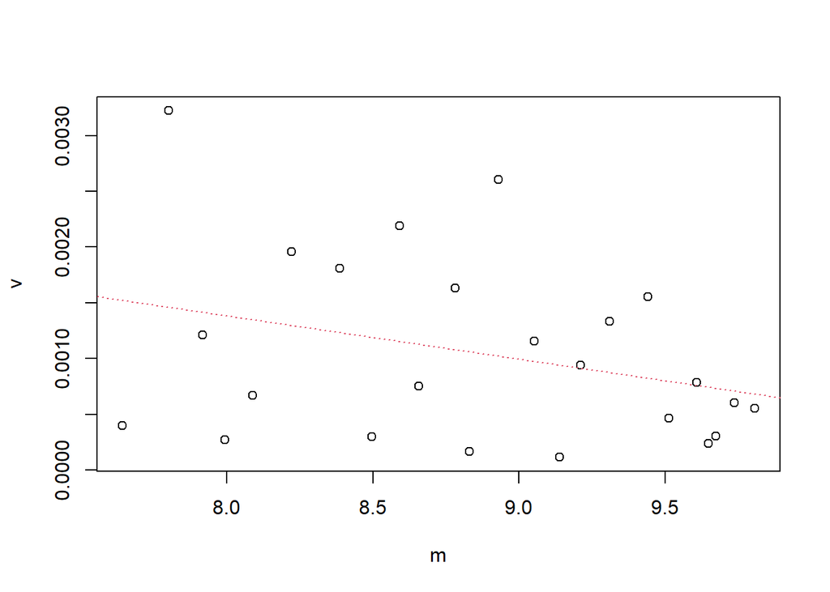

```r
m<-apply(groupedlnserie,2,mean)
v<-apply(groupedlnserie,2,var)
plot(v~m)
abline(lm(v~m),col=2,lty=3)
```

#### Is the mean constant?

There is a clear almost-linear trend. We have to apply one regular difference trying to make the mean constant:

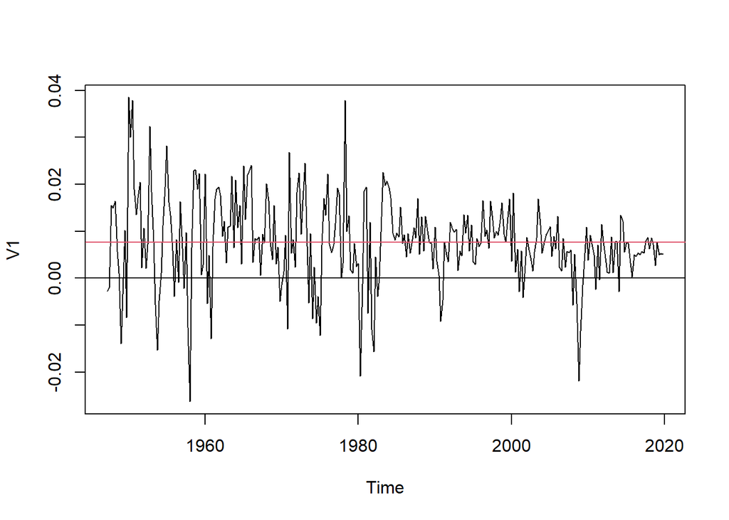

```r
d1lnserie=diff(lnserie)
plot(d1lnserie)
abline(h=0)
abline(h=mean(d1lnserie),col=2)
```

```r
mean(lnserie)
```

```
## [1] 8.866897
```

Mean seemingly constant, but different from zero!!!

#### Check for over-differentiation: Take an extra differentiation and compare the variances.

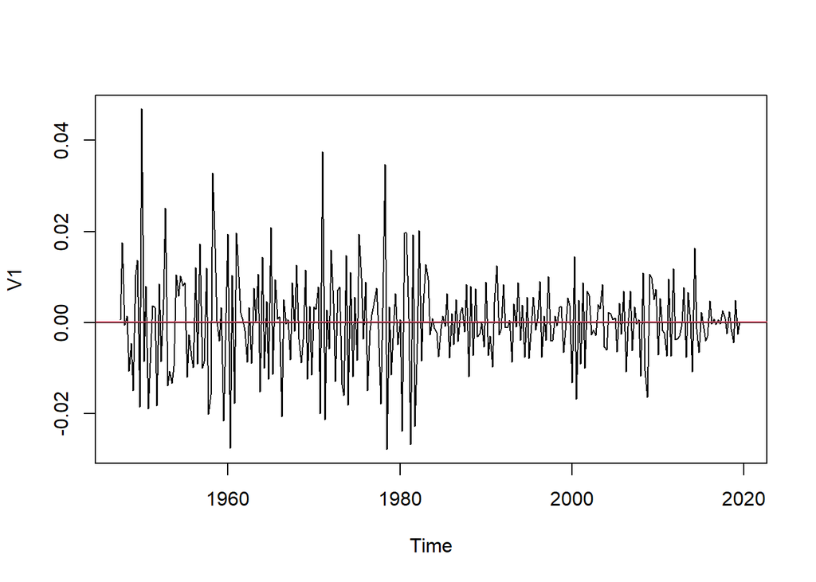

```r
d1d1lnserie=diff(d1lnserie)
plot(d1d1lnserie)
abline(h=0)
abline(h=mean(d1d1lnserie),col=2)
```

```r
var(lnserie)
```

```
##           V1
## V1 0.4445013
```

```r
var(d1lnserie)
```

```
##              V1
## V1 8.626093e-05
```

```r
var(d1d1lnserie)
```

```
##              V1
## V1 0.0001104663
```

#### Is an extra differentiation needed?

NOP! Observe that with extra regular difference the mean becomes zero, but the variance increases…

#### Is the current series already stationary? Plot the ACF and decide!!

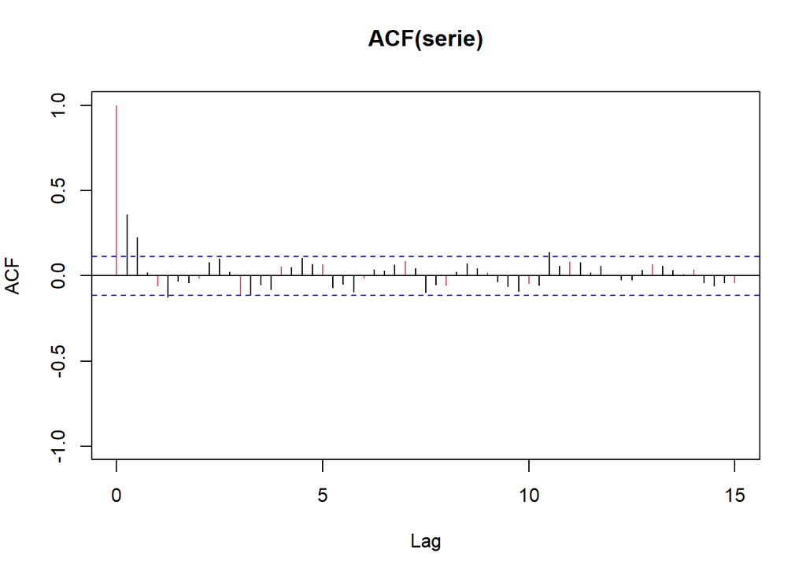

```r
par(mar = c(5, 4, 4, 2))
acf(d1lnserie,ylim=c(-1,1),lag.max=60,col=c(2,rep(1,3)), main ="ACF(serie)")
```

Notice that the ACF decays fast towards zero and thus the dependence structure depends only on the lag. Thus, the (1-B)log(GDPUSA) time series is already stationary!

In this case, the given series (1-B)log(GDPUSA) shows no seasonality, has constant mean and variance. Additionally, its covariance structure does not depends on the time-origin.

#### Final transformation for the GDPUSA series: $W_t=(1-B)\log X_t$

### GDPUSAvar: gross domestic product variation of the United States. Quarter I-1990 - Quarter IV-2019

Percent change over the previous period (quarter) of the gross domestic product of the United States; official web http://www.bea.gov/national/index.htm. Quarter I-1990 - Quarter IV-2019; 30 years. The series is seasonally adjusted.

### I. Exploratory data analysis and transformation into stationarity

#### Ia. Exploratory data analysis

Import the data

```r
(serie=ts((read.table("gdpUSAvar.dat",header=F)),start=1990,freq=4))
```

```
##      Qtr1 Qtr2 Qtr3 Qtr4
## 1990  4.4  1.5  0.3 -3.6
## 1991 -1.9  3.2  2.0  1.4
## 1992  4.9  4.4  4.0  4.2
## 1993  0.7  2.3  1.9  5.6
## 1994  3.9  5.5  2.4  4.7
## 1995  1.4  1.2  3.5  2.7
## 1996  3.0  6.8  3.6  4.2
## 1997  2.6  6.8  5.1  3.5
## 1998  4.1  3.8  5.1  6.6
## 1999  3.8  3.1  5.3  7.0
## 2000  1.5  7.5  0.5  2.5
## 2001 -1.1  2.4 -1.7  1.1
## 2002  3.5  2.4  1.8  0.6
## 2003  2.2  3.5  7.0  4.7
```

[output cut: 16 more lines]

Plot the time series GDPUSAvar

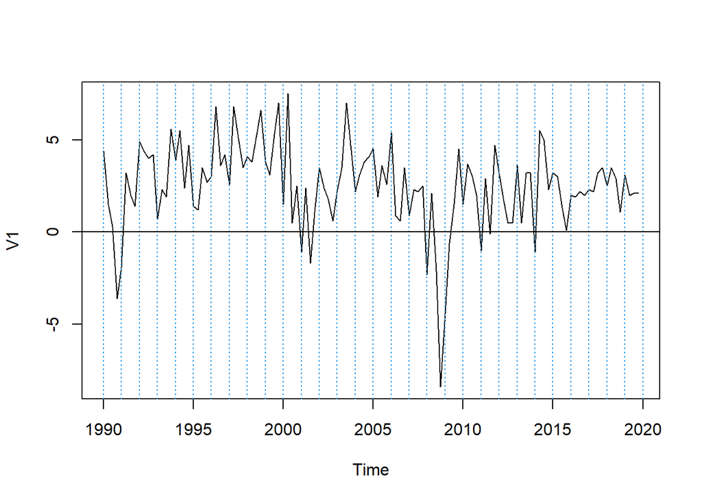

```r
plot(serie)
abline(v=1990:2020,col=4,lty=3)
abline(h=0)
```

#### Remarks…

- Mention/describe here all known events in the period of study that might have influenced the GDPUSAvar time series: Gulf war, Twin towers fall, financial crisis,…
- Provide your general statistical impressions. For instance, does it seems to be:
  - a seasonal component?
  - a global trend? A non-constant superposed to a non-constant mean behavior.
  - a non constant variance? Let’s check it all…

#### Ib. Tranforming series into a stationary one:

Is Variance constant?

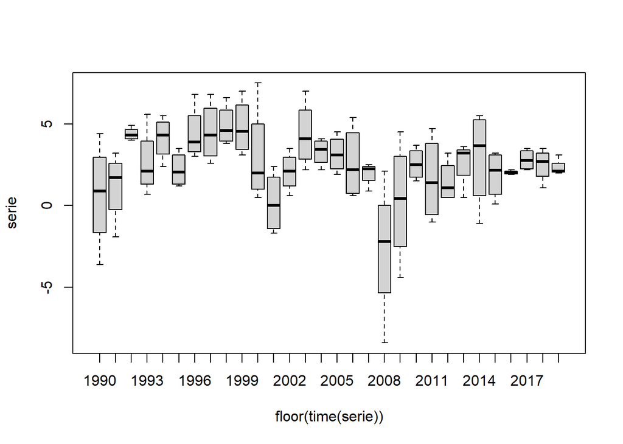

```r
boxplot(serie~floor(time(serie)))
```

Boxplots with only 4 observations? Better group observations of 2-3 years (8-12 quarters)?

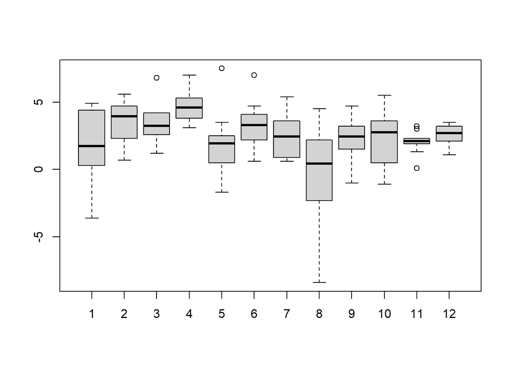

```r
groupedserie <- matrix(serie, ncol=12) #12 quarters=3yrs together=ncol=12
boxplot(groupedserie)
```

Thus, … the varianza is considered constant!

#### Is seasonality present?

Nop, GDPUSAvar series has been previously seasonally adjusted and it represents already percentage variation

#### Is the mean constant?

Plot again the whole time series together with its mean value

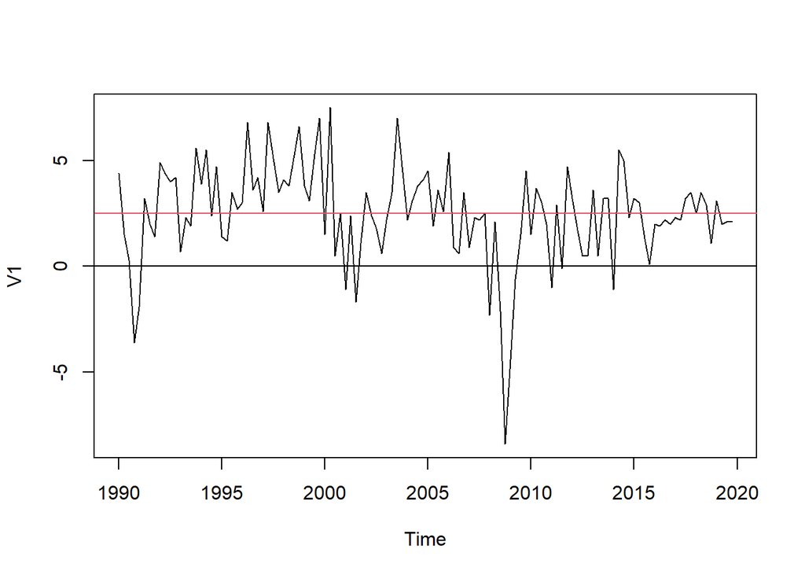

```r
plot(serie)
abline(h=0)
abline(h=mean(serie),col=2)
```

```r
mean(serie)
```

```
## [1] 2.49
```

Mean seemingly constant, but different from zero!!!

#### Check for over-differentiation: Take an extra differentiation and compare the variances.

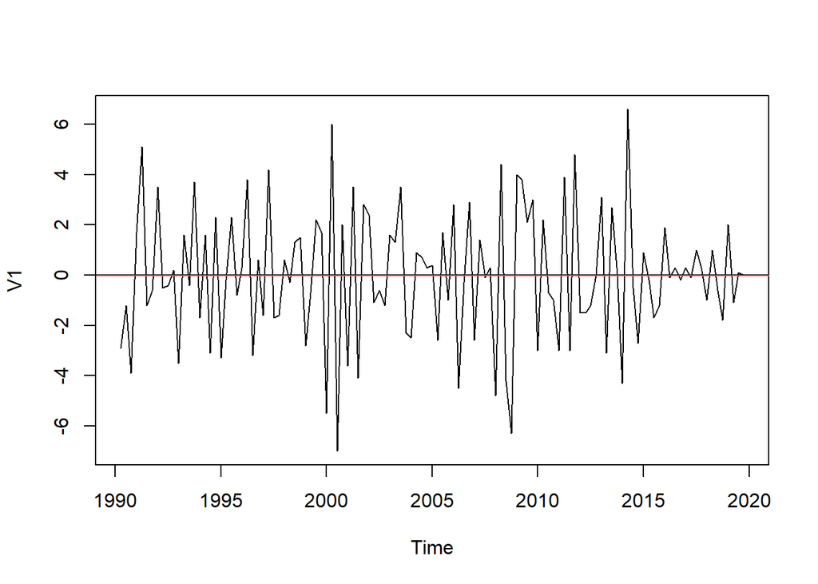

```r
d1serie=diff(serie)
plot(d1serie)
abline(h=0)
abline(h=mean(d1serie),col=2)
```

```r
var(serie)
```

```
##         V1
## V1 5.50763
```

```r
var(d1serie)
```

```
##          V1
## V1 6.840555
```

#### Is an extra differentiation needed?

NOP! Observe that with extra regular difference the mean becomes zero, but the variance increases…

#### Is the current series already stationary? Plot the ACF and decide!!

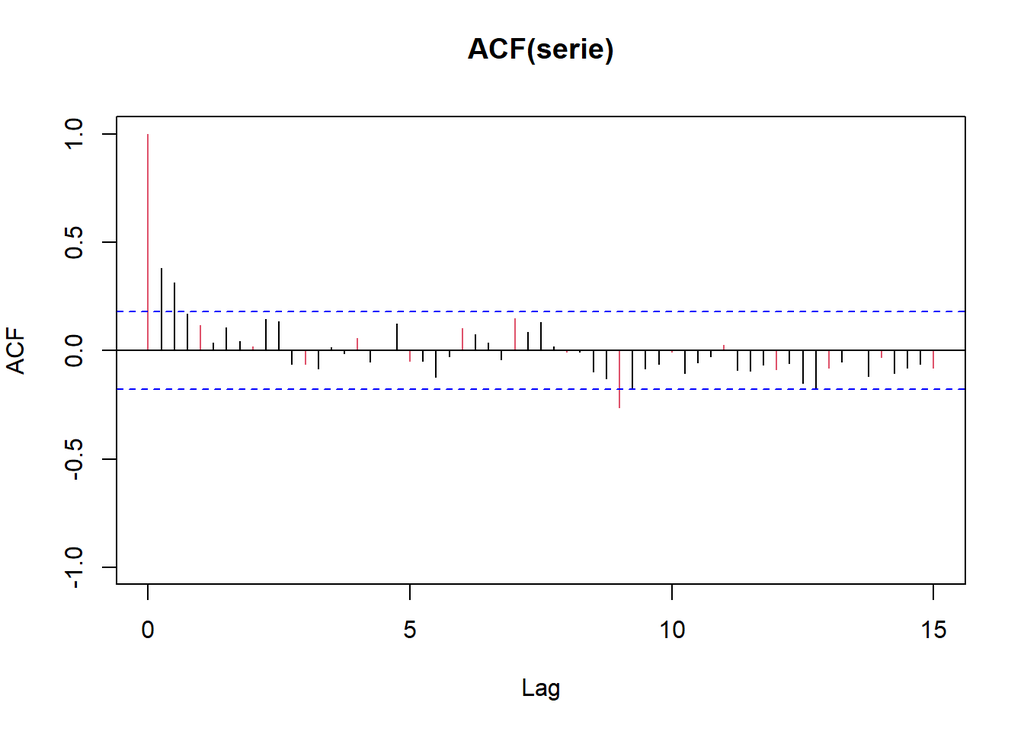

```r
par(mar = c(5, 4, 4, 2))
acf(serie,ylim=c(-1,1),lag.max=60,col=c(2,rep(1,3)), main ="ACF(serie)")
```

Notice that the ACF decays fast towards zero and thus the dependence structure depends only on the lag. Thus, the GDPUSAvar time series is already stationary!

In this case, the given series GDPUSAvar shows no seasonality, has constant mean and variance. Additionally, its covariance structure does not depends on the time-origin.

#### Final transformation for the GDPUSAvar series: $W_t= X_t$

### AIRBCN: monthly number of passengers of international flights in El Prat Airport (BCN)

### I. Exploratory data analysis and transformation into stationarity

#### Ia. Exploratory data analysis

Import the data (and express in “thousands of passengers”)

```r
(serie=ts((read.table("airbcn.dat",header=F))/1000,start=1990,freq=12))
```

```
##           Jan      Feb      Mar      Apr      May      Jun      Jul      Aug
## 1990  215.140  206.775  265.051  337.802  305.500  317.929  366.613  368.166
## 1991  186.726  146.031  228.635  275.171  277.792  293.507  332.409  374.133
## 1992  220.898  211.934  276.993  348.408  337.950  328.923  409.589  509.070
## 1993  238.525  241.993  310.758  373.203  331.335  345.269  405.114  443.800
## 1994  238.360  234.185  353.354  347.573  378.229  366.529  420.285  449.934
## 1995  275.047  263.823  366.320  427.152  389.170  393.027  444.125  468.968
## 1996  303.233  310.057  419.797  474.923  450.159  469.850  542.556  598.553
## 1997  344.489  354.464  504.734  522.173  559.120  559.823  636.634  726.352
## 1998  392.710  415.381  531.848  624.574  620.023  636.020  719.989  790.440
## 1999  450.834  474.974  629.476  665.749  743.300  720.149  828.583  899.438
## 2000  492.367  531.758  715.362  843.230  837.234  831.553  974.992 1033.456
## 2001  597.669  635.124  831.373  978.133  945.322 1010.645 1118.119 1178.222
## 2002  611.457  676.176  904.683  964.571  993.593 1024.443 1168.263 1242.020
## 2003  692.574  724.078  884.718 1003.668 1020.660 1106.228 1217.280 1341.990
```

[output cut: 47 more lines]

Plot the time series

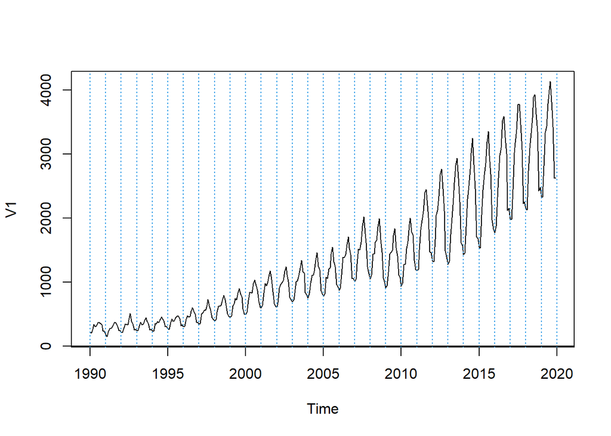

```r
plot(serie)
abline(v=1990:2020,col=4,lty=3)
abline(h=0)
```

#### Ib. Tranforming series into a stationary one:

Is Variance constant?

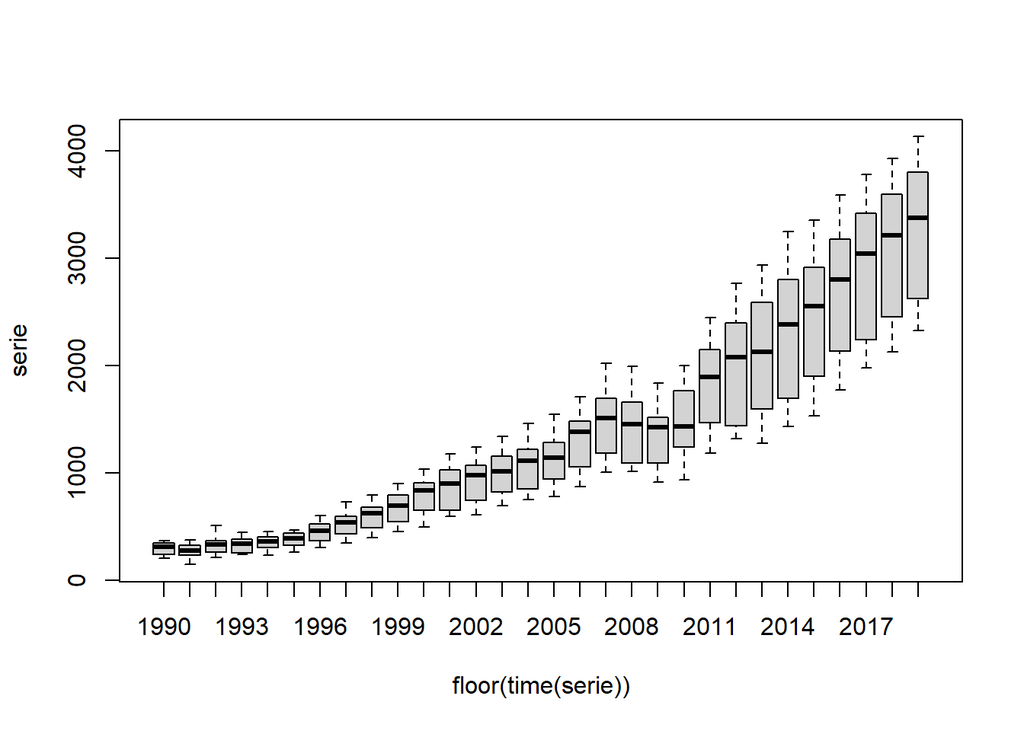

```r
boxplot(serie~floor(time(serie)))
```

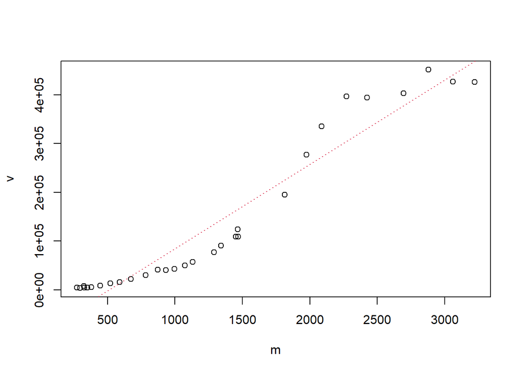

```r
m<-apply(matrix(serie,nrow=12),2,mean)
v<-apply(matrix(serie,nrow=12),2,var)
plot(v~m)
abline(lm(v~m),col=2,lty=3)
```

Thus, … the varianza is not considered constant! So, we change the scale by applying logarithms

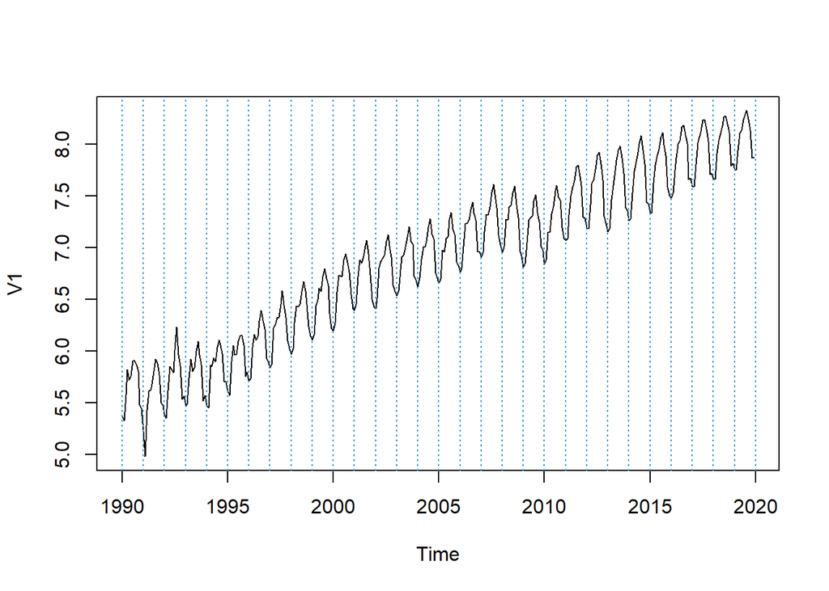

```r
lnserie=log(serie)
plot(lnserie)
abline(v=1990:2020,col=4,lty=3)
abline(h=0)
```

Let’s check the same plots for the transformed series

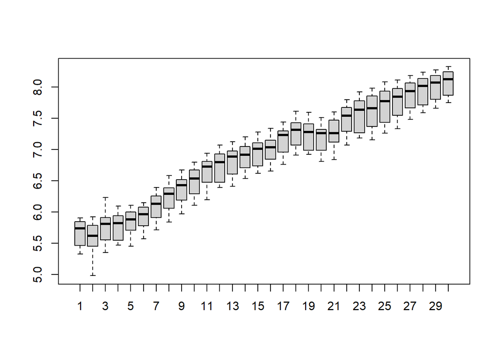

```r
matrixlnserie <- matrix(lnserie,nrow=12)
boxplot(matrixlnserie)
```

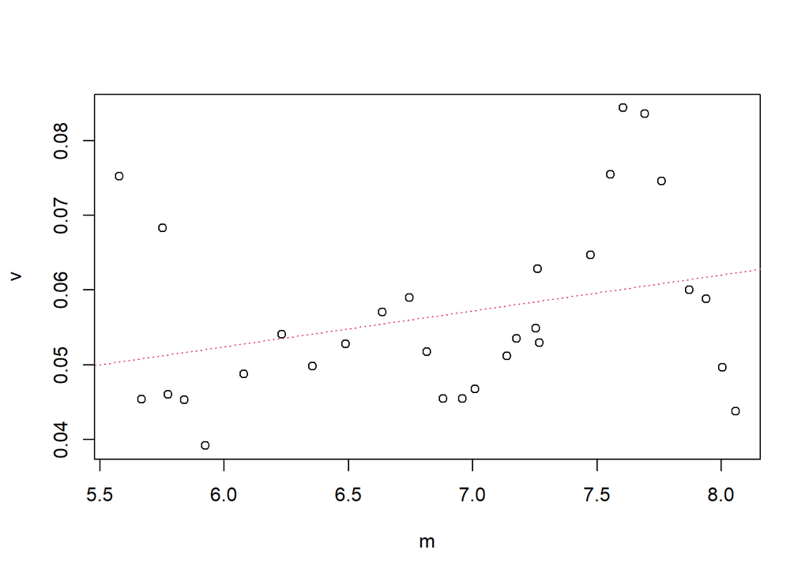

```r
m<-apply(matrixlnserie,2,mean)
v<-apply(matrixlnserie,2,var)
plot(v~m)
abline(lm(v~m),col=2,lty=3)
```

#### Is seasonality present?

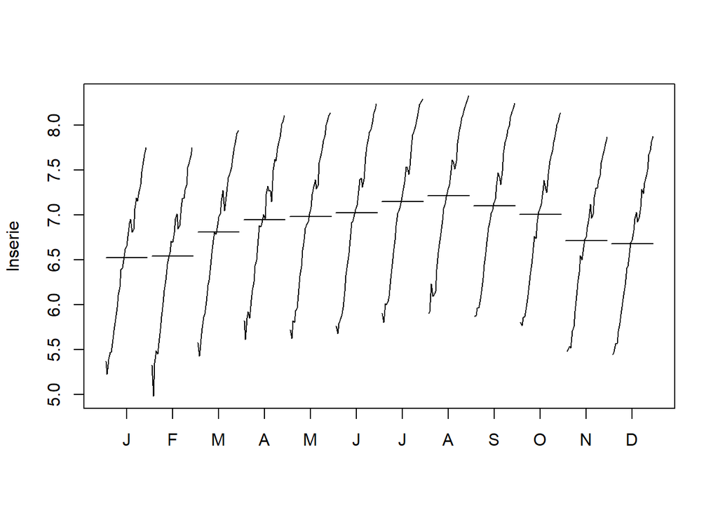

```r
monthplot(lnserie)
```

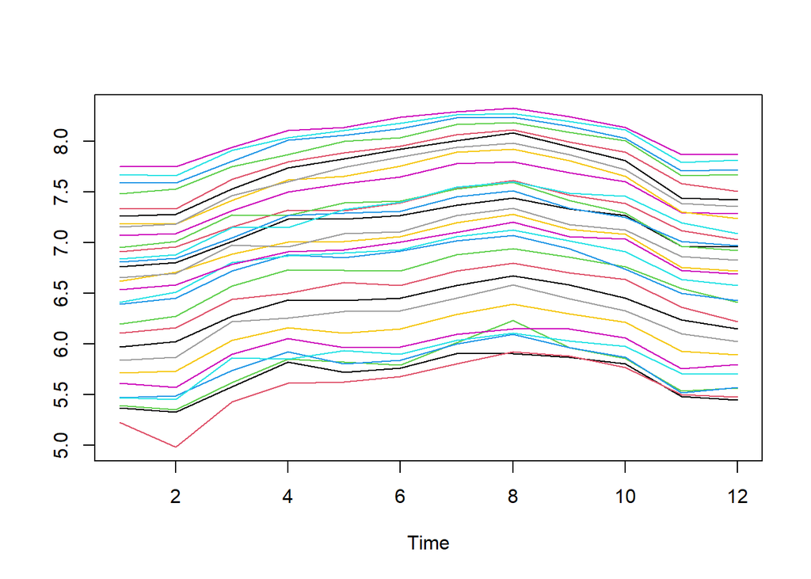

```r
ts.plot(matrix(lnserie,nrow=12),col=1:8)
```

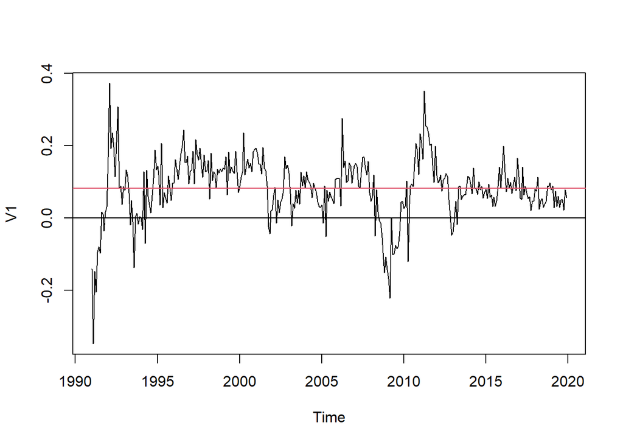

```r
d12lnserie<-diff(lnserie,lag=12)
plot(d12lnserie)
abline(h=0)
abline(h=mean(d12lnserie),col=2)
```

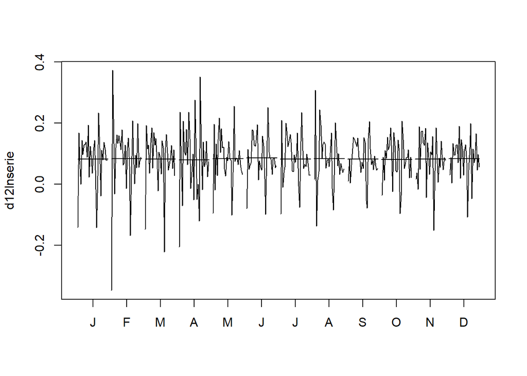

```r
monthplot(d12lnserie)
```

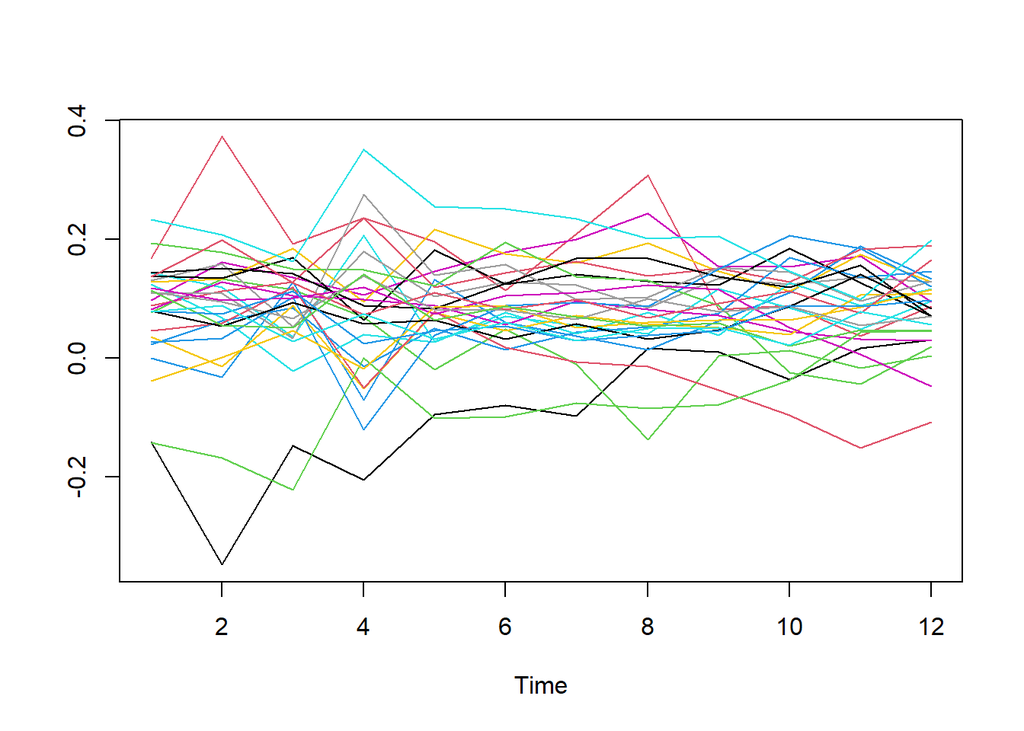

```r
ts.plot(matrix(d12lnserie,nrow=12),col=1:8)
```

#### Is the mean constant?

We have to apply one regular difference trying to make the mean constant:

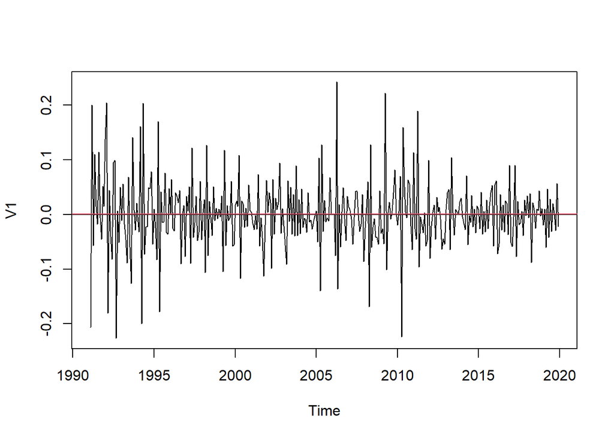

```r
d1d12lnserie=diff(d12lnserie)
plot(d1d12lnserie)
abline(h=0)
abline(h=mean(d1d12lnserie),col=2)
```

Mean seemingly constant equal to zero!!!

#### Check for over-differentiation: Take an extra differentiation and compare the variances.

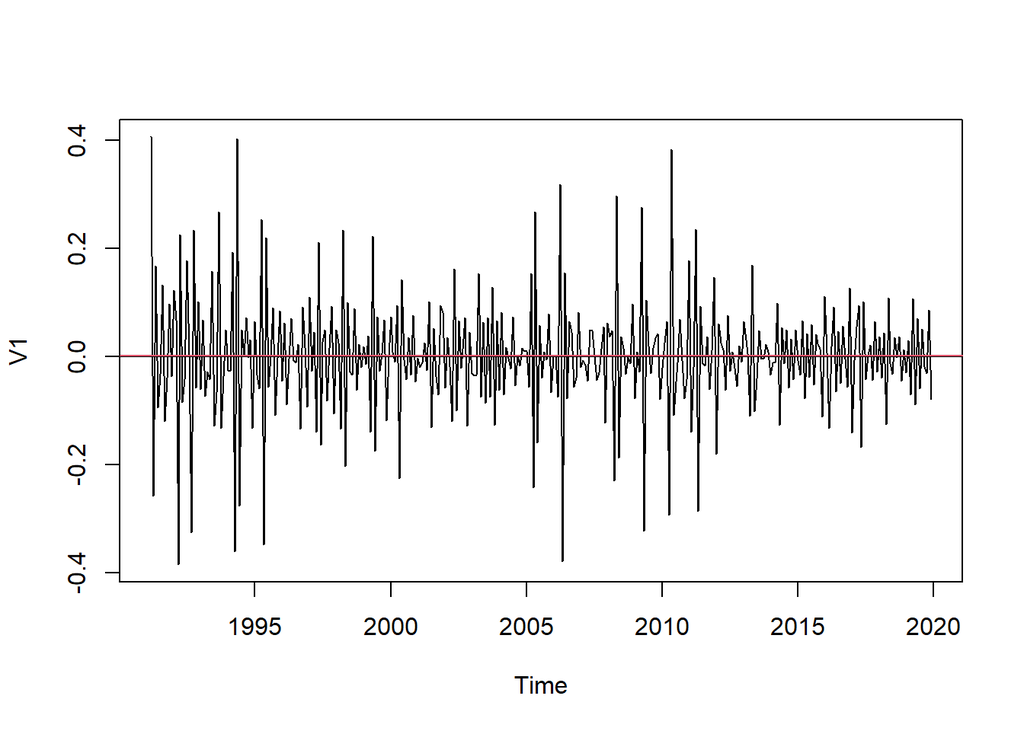

```r
d1d1d12lnserie=diff(d1d12lnserie)
plot(d1d1d12lnserie)
abline(h=0)
abline(h=mean(d1d1d12lnserie),col=2)
```

```r
var(lnserie)
```

```
##           V1
## V1 0.6321361
```

```r
var(d12lnserie)
```

```
##             V1
## V1 0.007310734
```

```r
var(d1d12lnserie)
```

```
##             V1
## V1 0.004211255
```

```r
var(d1d1d12lnserie)
```

```
##            V1
## V1 0.01234985
```

#### Is the current series already stationary? Plot the ACF and decide!!

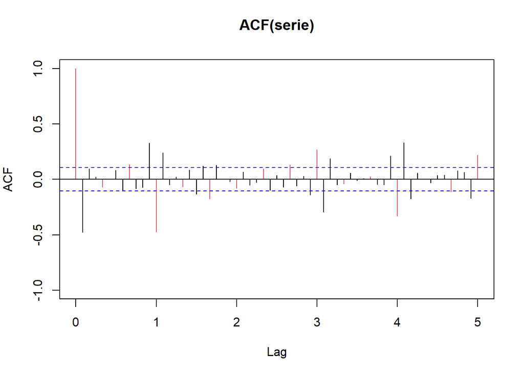

```r
par(mar = c(5, 4, 4, 2))
acf(d1d12lnserie,ylim=c(-1,1),lag.max=60,col=c(2,rep(1,3)), main ="ACF(serie)")
```

#### Final transformation for the AIRBCN series: $W_t=(1-B)(1-B^{12})\log X_t$